# Fixation Coverage & Time to First Interaction

> **Task constraint note:** AdSERP participants must click a result — no abandonment or query reformulation. First-viewport click rates and TTI may differ from naturalistic browsing. See findings caveats.

Two questions about the beginning of each SERP evaluation:

1. **Fixation coverage:** What share of results above the final click (or within max scroll depth) actually get fixated? This tells us whether users do a genuine sequential scan or skip results.
2. **Time to first interaction (TTI):** How long before the first mousemove, first scroll? What does the event timeline look like for users who click in the first viewport vs. those who scroll?

```python
# Ensure working directory is repo root
import os
if os.path.basename(os.getcwd()) == 'notebooks':
    os.chdir('..')

import os
import csv
import math
import xml.etree.ElementTree as ET
from collections import defaultdict
from bisect import bisect_right

import numpy as np
import matplotlib.pyplot as plt
from bs4 import BeautifulSoup

plt.rcParams.update({
    'figure.figsize': (12, 6),
    'figure.dpi': 150,
    'font.family': 'sans-serif',
    'font.size': 11,
    'axes.spines.top': False,
    'axes.spines.right': False,
})

DATA_DIR = 'AdSERP/data'
SERP_DIR = os.path.join(DATA_DIR, 'serps')
FIXATION_DIR = os.path.join(DATA_DIR, 'fixation-data')
MOUSE_DIR = os.path.join(DATA_DIR, 'mouse-movement-data')
METADATA_DIR = os.path.join(DATA_DIR, 'trial-metadata')

trial_ids = sorted(f.replace('.csv', '') for f in os.listdir(MOUSE_DIR) if f.endswith('.csv'))
print(f"Trials: {len(trial_ids)}")
```

```
Trials: 2776
```

## Shared utilities

Result-band estimation, scroll interpolation, fixation-to-result mapping — same approach as `serp_priming.ipynb`.

```python
def get_trial_meta(trial_id):
    path = os.path.join(METADATA_DIR, f'{trial_id}.xml')
    try:
        tree = ET.parse(path)
        doc_h = int(tree.find('.//document').text.split('x')[1])
        scr_h = int(tree.find('.//screen').text.split('x')[1])
        ts = int(tree.find('.//timestamp').text)
        return doc_h, scr_h, ts
    except:
        return None, None, None

def count_results_from_html(trial_id):
    path = os.path.join(SERP_DIR, f'{trial_id}.html')
    if not os.path.exists(path):
        return 0
    with open(path, encoding='utf-8', errors='replace') as f:
        soup = BeautifulSoup(f.read(), 'html.parser')
    return len(soup.find_all('h3'))

def result_bands(n_results, doc_height):
    header = 200
    per_res = (doc_height - 400) / max(n_results, 1)
    return [(header + i * per_res, header + (i + 1) * per_res) for i in range(n_results)]

def interpolate_scroll(t, scroll_ts, scroll_ys):
    if not scroll_ts:
        return 0.0
    if t <= scroll_ts[0]: return scroll_ys[0]
    if t >= scroll_ts[-1]: return scroll_ys[-1]
    idx = bisect_right(scroll_ts, t) - 1
    if idx < len(scroll_ts) - 1:
        frac = (t - scroll_ts[idx]) / max(scroll_ts[idx+1] - scroll_ts[idx], 1)
        return scroll_ys[idx] + frac * (scroll_ys[idx+1] - scroll_ys[idx])
    return scroll_ys[-1]

def load_mouse_events(trial_id):
    path = os.path.join(MOUSE_DIR, f'{trial_id}.csv')
    all_events, scrolls, clicks = [], [], []
    with open(path) as f:
        for r in csv.DictReader(f):
            t = int(float(r['timestamp']))
            evt = r['event']
            x, y = float(r['xpos']), float(r['ypos'])
            all_events.append((t, evt, x, y))
            if evt == 'scroll':
                scrolls.append((t, y))
            elif evt == 'click':
                clicks.append((t, x, y))
    return all_events, scrolls, clicks

def compute_fixation_per_result(trial_id, n_results, doc_height, scroll_ts, scroll_ys):
    bands = result_bands(n_results, doc_height)
    tops = [b[0] for b in bands]
    fix_per = defaultdict(float)
    fp = os.path.join(FIXATION_DIR, f'{trial_id}.csv')
    if not os.path.exists(fp):
        return None
    with open(fp) as f:
        for row in csv.DictReader(f):
            try:
                ft = int(float(row['timestamp']))
                fy = float(row['FPOGY'])
                fd = float(row['FPOGD'])
            except:
                continue
            page_y = fy + interpolate_scroll(ft, scroll_ts, scroll_ys)
            pos = bisect_right(tops, page_y) - 1
            if 0 <= pos < n_results:
                fix_per[pos] += fd
    return dict(fix_per)
```

## Part 1: Fixation coverage

For each trial, compute:

- **Click position** — which result the user clicked (scroll-corrected)
- **Max scroll position** — deepest result that was at least partially visible
- **Fixation per result** — total fixation duration on each result

Then ask: of results at or above the click / scroll boundary, how many got >0 fixation?

```python
def analyze_coverage(trial_id):
    doc_h, scr_h, t0 = get_trial_meta(trial_id)
    if not doc_h or not scr_h:
        return None
    n_res = count_results_from_html(trial_id)
    if n_res < 3:
        return None

    all_events, scrolls, clicks = load_mouse_events(trial_id)
    if not clicks:
        return None

    scroll_ts = [s[0] for s in scrolls]
    scroll_ys = [s[1] for s in scrolls]

    fix_per = compute_fixation_per_result(trial_id, n_res, doc_h, scroll_ts, scroll_ys)
    if fix_per is None:
        return None

    # Click position (scroll-corrected)
    ct, cx, cy = clicks[-1]
    click_page_y = cy + interpolate_scroll(ct, scroll_ts, scroll_ys)
    bands = result_bands(n_res, doc_h)
    tops = [b[0] for b in bands]
    click_pos = bisect_right(tops, click_page_y) - 1
    click_pos = max(0, min(click_pos, n_res - 1))

    # Max scroll depth
    max_scroll_y = max((s[1] for s in scrolls), default=0) + scr_h
    max_scroll_pos = 0
    for pos, (r_top, r_bot) in enumerate(bands):
        if r_top < max_scroll_y:
            max_scroll_pos = pos

    # First-viewport click?
    max_scroll_before_click = max((sy for st, sy in scrolls if st < ct), default=0)
    first_vp_click = max_scroll_before_click < 50

    # First viewport result count
    fv_n = sum(1 for r_top, r_bot in bands if r_top < scr_h)

    # Coverage metrics
    above_click = range(0, click_pos + 1)
    fixated_above_click = sum(1 for p in above_click if fix_per.get(p, 0) > 0)

    within_scroll = range(0, max_scroll_pos + 1)
    fixated_within_scroll = sum(1 for p in within_scroll if fix_per.get(p, 0) > 0)

    fv_fixated = sum(1 for p in range(fv_n) if fix_per.get(p, 0) > 0)

    return {
        'trial': trial_id,
        'pid': trial_id.split('-')[0],
        'n_results': n_res,
        'click_pos': click_pos,
        'max_scroll_pos': max_scroll_pos,
        'first_vp_click': first_vp_click,
        'fixated_above_click': fixated_above_click,
        'total_above_click': len(above_click),
        'fixated_within_scroll': fixated_within_scroll,
        'total_within_scroll': len(within_scroll),
        'fv_n': fv_n,
        'fv_fixated': fv_fixated,
        'fix_per': fix_per,
    }

print("Analyzing fixation coverage...")
coverage = []
for i, tid in enumerate(trial_ids):
    if (i+1) % 500 == 0:
        print(f"  {i+1}/{len(trial_ids)}...")
    r = analyze_coverage(tid)
    if r:
        coverage.append(r)

print(f"Processed: {len(coverage)}")

fv_trials = [r for r in coverage if r['first_vp_click']]
sc_trials = [r for r in coverage if not r['first_vp_click']]
print(f"First-viewport clicks: {len(fv_trials)} ({len(fv_trials)/len(coverage):.1%})")
print(f"Scrolled before click: {len(sc_trials)} ({len(sc_trials)/len(coverage):.1%})")
```

```
Analyzing fixation coverage...
```

```
  500/2776...
```

```
  1000/2776...
```

```
  1500/2776...
```

```
  2000/2776...
```

```
  2500/2776...
```

```
Processed: 2772
First-viewport clicks: 509 (18.4%)
Scrolled before click: 2263 (81.6%)
```

```python
# Coverage stats
shares_click = [r['fixated_above_click'] / r['total_above_click']
                for r in coverage if r['total_above_click'] > 0]
shares_scroll = [r['fixated_within_scroll'] / r['total_within_scroll']
                 for r in coverage if r['total_within_scroll'] > 0]

print(f"=== Results above the clicked result ===")
print(f"Mean share fixated: {np.mean(shares_click):.1%}")
print(f"Median: {np.median(shares_click):.1%}")
print(f"All fixated: {sum(1 for s in shares_click if s >= 1.0)} ({sum(1 for s in shares_click if s >= 1.0)/len(shares_click):.1%})")

print(f"\n=== Results within max scroll depth ===")
print(f"Mean share fixated: {np.mean(shares_scroll):.1%}")
print(f"Median: {np.median(shares_scroll):.1%}")

print(f"\n=== First-viewport fixation coverage ===")
fv_cov = [r['fv_fixated'] / r['fv_n'] for r in fv_trials if r['fv_n'] > 0]
sc_cov = [r['fv_fixated'] / r['fv_n'] for r in sc_trials if r['fv_n'] > 0]
print(f"FV clickers: {np.mean(fv_cov):.1%} of first-screen results fixated")
print(f"Scrollers:   {np.mean(sc_cov):.1%} of first-screen results fixated")

print(f"\n=== Coverage by click position ===")
print(f"{'Click':>6} {'Mean%':>7} {'Median%':>8} {'N':>6} {'Skip':>6}")
for cp in range(10):
    sub = [r for r in coverage if r['click_pos'] == cp and r['total_above_click'] > 0]
    if not sub: continue
    shr = [r['fixated_above_click'] / r['total_above_click'] for r in sub]
    skips = [r['total_above_click'] - r['fixated_above_click'] for r in sub]
    print(f"{cp:>6} {np.mean(shr):>6.1%} {np.median(shr):>7.1%} {len(sub):>6} {np.mean(skips):>5.1f}")
```

```
=== Results above the clicked result ===
Mean share fixated: 95.2%
Median: 100.0%
All fixated: 2189 (79.0%)

=== Results within max scroll depth ===
Mean share fixated: 82.7%
Median: 85.7%

=== First-viewport fixation coverage ===
FV clickers: 68.0% of first-screen results fixated
Scrollers:   91.7% of first-screen results fixated

=== Coverage by click position ===
 Click   Mean%  Median%      N   Skip
     0  99.4%  100.0%    489   0.0
     1  98.8%  100.0%    383   0.0
     2  98.7%  100.0%    387   0.0
     3  96.7%  100.0%    371   0.1
     4  96.8%  100.0%    260   0.2
     5  94.7%  100.0%    182   0.3
     6  92.8%  100.0%    158   0.5
     7  90.2%  100.0%    108   0.8
     8  86.6%   88.9%    107   1.2
     9  86.8%   90.0%     80   1.3
```

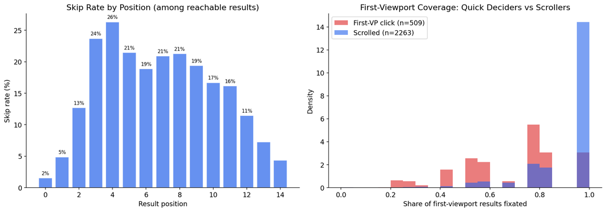

```python
# Skip rate by position (among reachable results)
pos_reach = defaultdict(int)
pos_fixated = defaultdict(int)
for r in coverage:
    boundary = max(r['click_pos'], r['max_scroll_pos'])
    for p in range(boundary + 1):
        pos_reach[p] += 1
        if r['fix_per'].get(p, 0) > 0:
            pos_fixated[p] += 1

fig, (ax1, ax2) = plt.subplots(1, 2, figsize=(14, 5))

# Left: skip rate by position
positions = sorted(p for p in pos_reach if pos_reach[p] >= 20)
skip_rates = [(1 - pos_fixated[p] / pos_reach[p]) * 100 for p in positions]
ax1.bar(positions, skip_rates, color='#2563eb', alpha=0.7, edgecolor='white')
ax1.set_xlabel('Result position')
ax1.set_ylabel('Skip rate (%)')
ax1.set_title('Skip Rate by Position (among reachable results)')
for p, sr in zip(positions, skip_rates):
    if p <= 12:
        ax1.text(p, sr + 0.5, f'{sr:.0f}%', ha='center', fontsize=8)

# Right: fixation coverage distribution — FV vs scrolled
bins = np.arange(0, 1.05, 0.05)
ax2.hist([r['fv_fixated'] / r['fv_n'] for r in fv_trials if r['fv_n'] > 0],
         bins=bins, alpha=0.6, color='#dc2626', label=f'First-VP click (n={len(fv_trials)})', density=True)
ax2.hist([r['fv_fixated'] / r['fv_n'] for r in sc_trials if r['fv_n'] > 0],
         bins=bins, alpha=0.6, color='#2563eb', label=f'Scrolled (n={len(sc_trials)})', density=True)
ax2.set_xlabel('Share of first-viewport results fixated')
ax2.set_ylabel('Density')
ax2.set_title('First-Viewport Coverage: Quick Deciders vs Scrollers')
ax2.legend()

plt.tight_layout()
plt.savefig('plots-v1/plot_coverage_skip_rate.png', dpi=200, bbox_inches='tight')
plt.show()
```

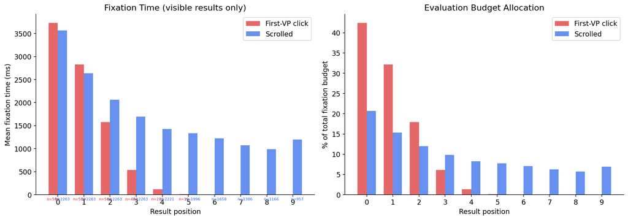

```
FV clickers: 509 trials with pos 0 visible, 215 with pos 4
Scrollers:   2263 trials with pos 0 visible, 957 with pos 9

FV budget: pos 0 gets 42% of fixation time, pos 1 gets 32%
SC budget: pos 0 gets 21% of fixation time, pos 1 gets 15%
```

```python
# Fixation time by position — conditioned on visibility
# Only include a result in the average if it was actually visible to this user
# (within first viewport for FV clickers, within max scroll depth for scrollers)

fig, axes = plt.subplots(1, 2, figsize=(14, 5))

# --- Left panel: conditioned on visibility ---
fv_by_pos_vis = defaultdict(list)
sc_by_pos_vis = defaultdict(list)
fv_n_vis = defaultdict(int)
sc_n_vis = defaultdict(int)

for r in coverage:
    is_fv = r['first_vp_click']
    # Visible results: up to first-viewport count (FV clickers) or max scroll pos (scrollers)
    if is_fv:
        visible_limit = r['fv_n']
    else:
        visible_limit = r['max_scroll_pos'] + 1

    target = fv_by_pos_vis if is_fv else sc_by_pos_vis
    n_target = fv_n_vis if is_fv else sc_n_vis
    for p in range(min(visible_limit, 10)):
        target[p].append(r['fix_per'].get(p, 0))
        n_target[p] += 1

positions = range(10)
fv_means_vis = [np.mean(fv_by_pos_vis[p]) if fv_by_pos_vis[p] else 0 for p in positions]
sc_means_vis = [np.mean(sc_by_pos_vis[p]) if sc_by_pos_vis[p] else 0 for p in positions]
fv_ns = [len(fv_by_pos_vis[p]) for p in positions]
sc_ns = [len(sc_by_pos_vis[p]) for p in positions]

ax = axes[0]
x = np.arange(10)
w = 0.35
bars_fv = ax.bar(x - w/2, fv_means_vis, w, color='#dc2626', alpha=0.7,
                  label=f'First-VP click')
bars_sc = ax.bar(x + w/2, sc_means_vis, w, color='#2563eb', alpha=0.7,
                  label=f'Scrolled')
ax.set_xlabel('Result position')
ax.set_ylabel('Mean fixation time (ms)')
ax.set_title('Fixation Time (visible results only)')
ax.legend()
ax.set_xticks(x)

# Add n counts below bars
for p in positions:
    if fv_ns[p] > 0:
        ax.text(p - w/2, -120, f'n={fv_ns[p]}', ha='center', fontsize=6, color='#dc2626')
    if sc_ns[p] > 0:
        ax.text(p + w/2, -120, f'n={sc_ns[p]}', ha='center', fontsize=6, color='#2563eb')

# --- Right panel: share of evaluation budget ---
fv_total = sum(fv_means_vis[:5])  # FV clickers see ~5 results
sc_total = sum(sc_means_vis)

fv_share = [m / fv_total * 100 if fv_total > 0 else 0 for m in fv_means_vis]
sc_share = [m / sc_total * 100 if sc_total > 0 else 0 for m in sc_means_vis]

ax = axes[1]
ax.bar(x - w/2, fv_share, w, color='#dc2626', alpha=0.7, label='First-VP click')
ax.bar(x + w/2, sc_share, w, color='#2563eb', alpha=0.7, label='Scrolled')
ax.set_xlabel('Result position')
ax.set_ylabel('% of total fixation budget')
ax.set_title('Evaluation Budget Allocation')
ax.legend()
ax.set_xticks(x)

plt.tight_layout()
plt.savefig('plots-v1/plot_coverage_fixtime_by_group.png', dpi=200, bbox_inches='tight')
plt.show()

print(f"FV clickers: {fv_ns[0]} trials with pos 0 visible, {fv_ns[4]} with pos 4")
print(f"Scrollers:   {sc_ns[0]} trials with pos 0 visible, {sc_ns[9]} with pos 9")
print(f"\nFV budget: pos 0 gets {fv_share[0]:.0f}% of fixation time, pos 1 gets {fv_share[1]:.0f}%")
print(f"SC budget: pos 0 gets {sc_share[0]:.0f}% of fixation time, pos 1 gets {sc_share[1]:.0f}%")
```

## Part 2: Time to First Interaction (TTI)

How do users begin their SERP journey? We measure:

- **TTI (any)** — first mousemove or scroll event
- **TTI (scroll)** — first scroll event specifically
- **Time to click** — total decision time

Segmented by whether the user ultimately clicked in the first viewport (no scroll) or scrolled first.

```python
def analyze_tti(trial_id):
    doc_h, scr_h, page_load = get_trial_meta(trial_id)
    if not doc_h or not scr_h or not page_load:
        return None

    all_events, scrolls, clicks = load_mouse_events(trial_id)
    if not all_events or not clicks:
        return None

    t0 = min(page_load * 1000, all_events[0][0])
    click_t = clicks[-1][0]

    first_scroll = scrolls[0][0] if scrolls else None
    first_move = None
    for t, evt, x, y in all_events:
        if evt == 'mousemove':
            first_move = t
            break

    max_scroll_before_click = max((sy for st, sy in scrolls if st < click_t), default=0)
    first_vp_click = max_scroll_before_click < 50

    return {
        'trial': trial_id,
        'pid': trial_id.split('-')[0],
        'tti_any_ms': all_events[0][0] - t0,
        'tti_scroll_ms': (first_scroll - t0) if first_scroll else None,
        'tti_move_ms': (first_move - t0) if first_move else None,
        'time_to_click_ms': click_t - t0,
        'first_vp_click': first_vp_click,
        'n_events': len(all_events),
        'n_scrolls_before_click': sum(1 for st, sy in scrolls if st < click_t),
    }

print("Analyzing TTI...")
tti_data = []
for i, tid in enumerate(trial_ids):
    if (i+1) % 500 == 0:
        print(f"  {i+1}/{len(trial_ids)}...")
    r = analyze_tti(tid)
    if r:
        tti_data.append(r)

fv_tti = [r for r in tti_data if r['first_vp_click']]
sc_tti = [r for r in tti_data if not r['first_vp_click']]

print(f"\nProcessed: {len(tti_data)}")
print(f"First-VP: {len(fv_tti)} ({len(fv_tti)/len(tti_data):.1%})")
print(f"Scrolled: {len(sc_tti)} ({len(sc_tti)/len(tti_data):.1%})")

print(f"\n{'Metric':<25} {'First-VP':>12} {'Scrolled':>12}")
print(f"{'-'*49}")
m = lambda vals: f"{np.median(vals)/1000:.1f}s"
print(f"{'TTI (first move)':<25} {m([r['tti_move_ms'] for r in fv_tti if r['tti_move_ms'] is not None and r['tti_move_ms'] >= 0]):>12} {m([r['tti_move_ms'] for r in sc_tti if r['tti_move_ms'] is not None and r['tti_move_ms'] >= 0]):>12}")
print(f"{'TTI (first scroll)':<25} {'—':>12} {m([r['tti_scroll_ms'] for r in sc_tti if r['tti_scroll_ms'] is not None and r['tti_scroll_ms'] >= 0]):>12}")
print(f"{'Time to click':<25} {m([r['time_to_click_ms'] for r in fv_tti if r['time_to_click_ms'] > 0]):>12} {m([r['time_to_click_ms'] for r in sc_tti if r['time_to_click_ms'] > 0]):>12}")
```

```
Analyzing TTI...
```

```
  500/2776...
```

```
  1000/2776...
```

```
  1500/2776...
```

```
  2000/2776...
```

```
  2500/2776...
```

```
Processed: 2775
First-VP: 511 (18.4%)
Scrolled: 2264 (81.6%)

Metric                        First-VP     Scrolled
-------------------------------------------------
TTI (first move)                  1.7s         1.7s
TTI (first scroll)                   —         5.9s
Time to click                    11.4s        23.8s
```

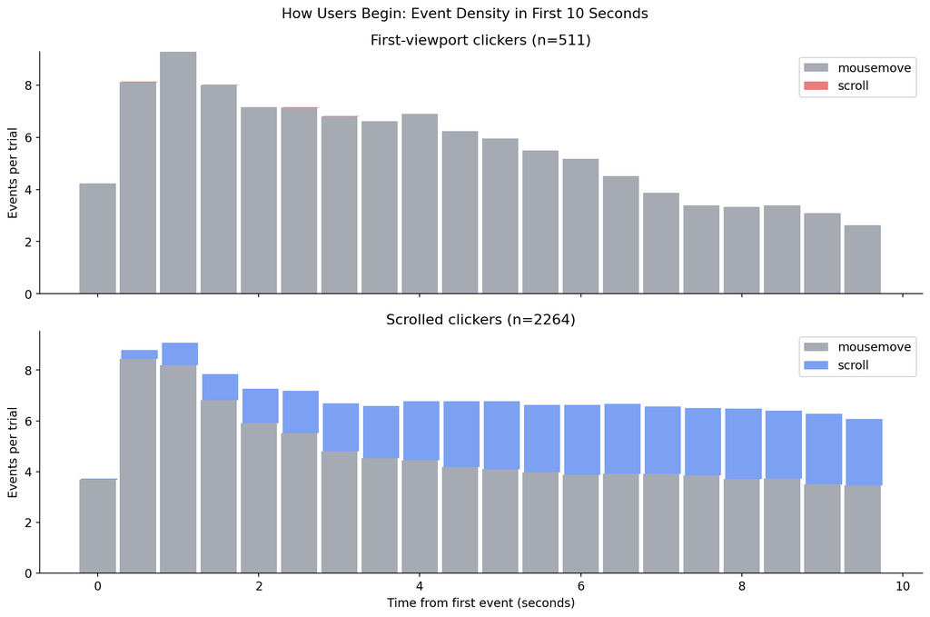

```python
# Event density timeline — first 10 seconds, 500ms bins
fig, (ax1, ax2) = plt.subplots(2, 1, figsize=(12, 8), sharex=True)

for ax, subset, label, color in [
    (ax1, fv_tti, 'First-viewport clickers', '#dc2626'),
    (ax2, sc_tti, 'Scrolled clickers', '#2563eb'),
]:
    move_density = defaultdict(int)
    scroll_density = defaultdict(int)
    click_density = defaultdict(int)
    n = len(subset)

    for trial in subset:
        # Reload raw events for timeline
        all_events, scrolls, clicks = load_mouse_events(trial['trial'])
        t0 = all_events[0][0] if all_events else 0
        for t, evt, x, y in all_events:
            dt = t - t0
            if dt > 10000:
                break
            bucket = int(dt / 500) * 500
            if evt == 'mousemove':
                move_density[bucket] += 1
            elif evt == 'scroll':
                scroll_density[bucket] += 1
        for ct, cx, cy in clicks:
            dt = ct - t0
            if dt <= 10000:
                click_density[int(dt / 500) * 500] += 1

    bins = np.arange(0, 10000, 500)
    ax.bar(bins/1000, [move_density[b]/n for b in bins], width=0.45, alpha=0.6,
           color='#6b7280', label='mousemove')
    ax.bar(bins/1000 + 0.02, [scroll_density[b]/n for b in bins], width=0.45, alpha=0.6,
           color=color, label='scroll', bottom=[move_density[b]/n for b in bins])
    ax.set_ylabel('Events per trial')
    ax.set_title(f'{label} (n={n})')
    ax.legend(loc='upper right')

ax2.set_xlabel('Time from first event (seconds)')
plt.suptitle('How Users Begin: Event Density in First 10 Seconds', fontsize=13)
plt.tight_layout()
plt.savefig('plots-v1/plot_tti_event_density.png', dpi=200, bbox_inches='tight')
plt.show()
```

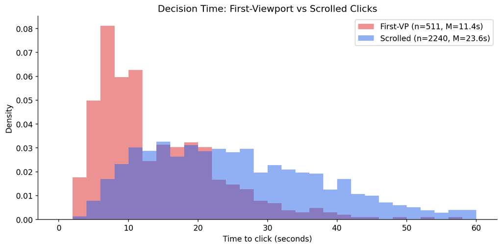

```
First-VP clickers decide 2.1x faster (median).
But they also look at far fewer results — is this satisficing or confidence?
```

```python
# Time-to-click distributions
fig, ax = plt.subplots(figsize=(10, 5))

ttc_fv = [r['time_to_click_ms']/1000 for r in fv_tti if 0 < r['time_to_click_ms']/1000 < 60]
ttc_sc = [r['time_to_click_ms']/1000 for r in sc_tti if 0 < r['time_to_click_ms']/1000 < 60]

bins = np.arange(0, 62, 2)
ax.hist(ttc_fv, bins=bins, alpha=0.5, color='#dc2626', density=True,
        label=f'First-VP (n={len(ttc_fv)}, M={np.median(ttc_fv):.1f}s)')
ax.hist(ttc_sc, bins=bins, alpha=0.5, color='#2563eb', density=True,
        label=f'Scrolled (n={len(ttc_sc)}, M={np.median(ttc_sc):.1f}s)')
ax.set_xlabel('Time to click (seconds)')
ax.set_ylabel('Density')
ax.set_title('Decision Time: First-Viewport vs Scrolled Clicks')
ax.legend()

plt.tight_layout()
plt.savefig('plots-v1/plot_tti_click_time.png', dpi=200, bbox_inches='tight')
plt.show()

print(f"First-VP clickers decide {np.median(ttc_sc)/np.median(ttc_fv):.1f}x faster (median).")
print(f"But they also look at far fewer results — is this satisficing or confidence?")
```

## Part 3: TTI as Individual Processing Speed Calibrator

Peter Dixon-Moses hypothesized that time-to-first-interaction could calibrate individual information processing speed — a session-start signal available without any training data. If TTI predicts how long a user spends evaluating each result, we can establish per-user baselines from the first few seconds of behavior.

We test this at three levels:

1. **User-level:** Does median TTI correlate with mean fixation time and viewport time per result?
2. **Calibration split:** Do the first 5 trials' TTI predict evaluation speed in remaining trials?
3. **Per-position:** Does the TTI signal hold across result positions, or only for early results?

```python
from scipy import stats

# Compute per-result fixation + viewport time for every trial
# (reuses scroll interpolation and result bands from Part 1)

print("Computing per-result evaluation metrics...")
eval_rows = []

for i, tid in enumerate(trial_ids):
    if (i+1) % 500 == 0:
        print(f"  {i+1}/{len(trial_ids)}...")

    doc_h, scr_h, page_load = get_trial_meta(tid)
    if not doc_h or not scr_h or not page_load:
        continue

    n_res = count_results_from_html(tid)
    if n_res < 3:
        continue

    all_events, scrolls, clicks = load_mouse_events(tid)
    if not all_events or not clicks:
        continue

    t0 = min(page_load * 1000, all_events[0][0])
    click_t = clicks[-1][0]

    # TTI metrics
    first_move_t = next((t for t, evt, x, y in all_events if evt == 'mousemove'), None)
    first_scroll_t = scrolls[0][0] if scrolls else None
    tti_move = (first_move_t - t0) if first_move_t else None
    tti_scroll = (first_scroll_t - t0) if first_scroll_t else None

    pid = tid.split('-')[0]
    scroll_ts = [s[0] for s in scrolls]
    scroll_ys = [s[1] for s in scrolls]

    # Per-result fixation
    bands = result_bands(n_res, doc_h)
    tops = [b[0] for b in bands]
    fix_per = defaultdict(float)
    fp = os.path.join(FIXATION_DIR, f'{tid}.csv')
    if not os.path.exists(fp):
        continue
    with open(fp) as f:
        for row in csv.DictReader(f):
            try:
                ft = int(float(row['timestamp']))
                fy = float(row['FPOGY'])
                fd = float(row['FPOGD'])
            except: continue
            page_y = fy + interpolate_scroll(ft, scroll_ts, scroll_ys)
            pos = bisect_right(tops, page_y) - 1
            if 0 <= pos < n_res:
                fix_per[pos] += fd

    # Per-result viewport time
    vp_time = defaultdict(float)
    for ei in range(len(scrolls) - 1):
        t_s, sy = scrolls[ei]
        t_next = scrolls[ei+1][0]
        dt = t_next - t_s
        if dt <= 0 or dt > 30000: continue
        vp_top, vp_bot = sy, sy + scr_h
        for pos, (r_top, r_bot) in enumerate(bands):
            r_h = r_bot - r_top
            vis = max(0, min(r_bot, vp_bot) - max(r_top, vp_top))
            if vis >= r_h * 0.5:
                vp_time[pos] += dt

    if not scrolls:
        trial_dur = click_t - t0
        for pos, (r_top, r_bot) in enumerate(bands):
            if r_top < scr_h:
                vp_time[pos] = trial_dur

    for pos in range(min(n_res, 10)):
        fm = fix_per.get(pos, 0)
        vm = vp_time.get(pos, 0)
        if fm > 0:
            eval_rows.append({
                'pid': pid, 'trial': tid, 'position': pos,
                'fixation_ms': fm, 'viewport_ms': vm,
                'tti_move': tti_move, 'tti_scroll': tti_scroll,
                'time_to_click': click_t - t0,
            })

print(f"Observations: {len(eval_rows)} (trial × result)")
print(f"Participants: {len(set(r['pid'] for r in eval_rows))}")
```

```
Computing per-result evaluation metrics...
```

```
  500/2776...
```

```
  1000/2776...
```

```
  1500/2776...
```

```
  2000/2776...
```

```
  2500/2776...
```

```
Observations: 18281 (trial × result)
Participants: 47
```

```python
# Aggregate per user
by_pid = defaultdict(list)
for r in eval_rows:
    by_pid[r['pid']].append(r)

user_tti = []
for pid, rows in by_pid.items():
    ttis_move = [r['tti_move'] for r in rows if r['tti_move'] is not None and r['tti_move'] >= 0]
    ttis_scroll = [r['tti_scroll'] for r in rows if r['tti_scroll'] is not None and r['tti_scroll'] >= 0]

    # Calibration split: first 5 trials → rest
    trials_ordered = sorted(set(r['trial'] for r in rows))
    calib_trials = set(trials_ordered[:5])
    calib_tti = [r['tti_move'] for r in rows if r['trial'] in calib_trials
                  and r['tti_move'] is not None and r['tti_move'] >= 0]
    test_rows = [r for r in rows if r['trial'] not in calib_trials]

    if not calib_tti or not test_rows:
        continue

    user_tti.append({
        'pid': pid,
        'median_tti_move': np.median(ttis_move) if ttis_move else None,
        'median_tti_scroll': np.median(ttis_scroll) if ttis_scroll else None,
        'calib_tti': np.median(calib_tti),
        'mean_fix': np.mean([r['fixation_ms'] for r in rows]),
        'mean_vp': np.mean([r['viewport_ms'] for r in rows if r['viewport_ms'] > 0]),
        'mean_ttc': np.mean([r['time_to_click'] for r in rows]) / 1000,
        'test_mean_fix': np.mean([r['fixation_ms'] for r in test_rows]),
        'test_mean_vp': np.mean([r['viewport_ms'] for r in test_rows if r['viewport_ms'] > 0]) if [r for r in test_rows if r['viewport_ms'] > 0] else 0,
    })

# --- User-level correlations ---
tti_move = [u['median_tti_move'] for u in user_tti if u['median_tti_move'] is not None]
fix_vals = [u['mean_fix'] for u in user_tti if u['median_tti_move'] is not None]
vp_vals = [u['mean_vp'] for u in user_tti if u['median_tti_move'] is not None]
ttc_vals = [u['mean_ttc'] for u in user_tti if u['median_tti_move'] is not None]

r_fix, p_fix = stats.pearsonr(tti_move, fix_vals)
r_vp, p_vp = stats.pearsonr(tti_move, vp_vals)
r_ttc, p_ttc = stats.pearsonr(tti_move, ttc_vals)

print(f"User-level correlations (N={len(tti_move)}):")
print(f"  TTI (move) → Fix/result:    r={r_fix:.3f}, p={p_fix:.4f}")
print(f"  TTI (move) → VP/result:     r={r_vp:.3f}, p={p_vp:.4f}")
print(f"  TTI (move) → Time-to-click: r={r_ttc:.3f}, p={p_ttc:.4f}")

# TTI scroll — stronger signal
scroll_users = [u for u in user_tti if u['median_tti_scroll'] is not None]
tti_s = [u['median_tti_scroll'] for u in scroll_users]
fix_s = [u['mean_fix'] for u in scroll_users]
vp_s = [u['mean_vp'] for u in scroll_users]
r_sf, p_sf = stats.pearsonr(tti_s, fix_s)
r_sv, p_sv = stats.pearsonr(tti_s, vp_s)
print(f"\n  TTI (scroll) → Fix/result:  r={r_sf:.3f}, p={p_sf:.4f} (n={len(scroll_users)})")
print(f"  TTI (scroll) → VP/result:   r={r_sv:.3f}, p={p_sv:.4f}")

# Calibration split
calib = [u['calib_tti'] for u in user_tti]
t_fix = [u['test_mean_fix'] for u in user_tti]
t_vp = [u['test_mean_vp'] for u in user_tti]
r_cf, p_cf = stats.pearsonr(calib, t_fix)
r_cv, p_cv = stats.pearsonr(calib, t_vp)
print(f"\nCalibration (first 5 trials TTI → remaining trials):")
print(f"  Calib TTI → test fix/result: r={r_cf:.3f}, p={p_cf:.4f}")
print(f"  Calib TTI → test VP/result:  r={r_cv:.3f}, p={p_cv:.4f}")
```

```
User-level correlations (N=47):
  TTI (move) → Fix/result:    r=0.460, p=0.0011
  TTI (move) → VP/result:     r=0.358, p=0.0135
  TTI (move) → Time-to-click: r=0.417, p=0.0036

  TTI (scroll) → Fix/result:  r=0.771, p=0.0000 (n=46)
  TTI (scroll) → VP/result:   r=0.735, p=0.0000

Calibration (first 5 trials TTI → remaining trials):
  Calib TTI → test fix/result: r=0.422, p=0.0032
  Calib TTI → test VP/result:  r=0.241, p=0.1034
```

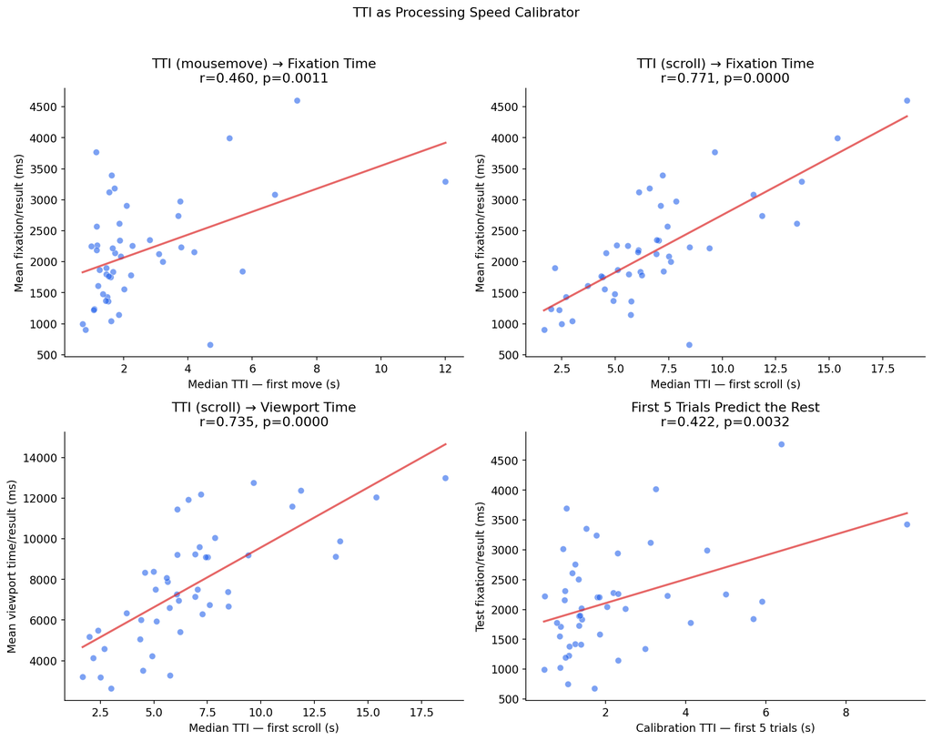

```python
# Scatter plots: TTI as calibrator
fig, axes = plt.subplots(2, 2, figsize=(13, 10))

def scatter_with_fit(ax, xs, ys, xlabel, ylabel, title):
    ax.scatter(xs, ys, s=40, alpha=0.6, color='#2563eb', edgecolor='white', linewidth=0.5)
    r, p = stats.pearsonr(xs, ys)
    # Fit line
    coef = np.polyfit(xs, ys, 1)
    x_fit = np.linspace(min(xs), max(xs), 100)
    ax.plot(x_fit, np.polyval(coef, x_fit), color='#dc2626', linewidth=2, alpha=0.7)
    ax.set_xlabel(xlabel)
    ax.set_ylabel(ylabel)
    ax.set_title(f'{title}\nr={r:.3f}, p={p:.4f}')

# TTI (move) → fixation
scatter_with_fit(axes[0,0],
    [u['median_tti_move']/1000 for u in user_tti if u['median_tti_move'] is not None],
    [u['mean_fix'] for u in user_tti if u['median_tti_move'] is not None],
    'Median TTI — first move (s)', 'Mean fixation/result (ms)',
    'TTI (mousemove) → Fixation Time')

# TTI (scroll) → fixation — the stronger signal
scatter_with_fit(axes[0,1],
    [u['median_tti_scroll']/1000 for u in scroll_users],
    [u['mean_fix'] for u in scroll_users],
    'Median TTI — first scroll (s)', 'Mean fixation/result (ms)',
    'TTI (scroll) → Fixation Time')

# TTI (scroll) → viewport time
scatter_with_fit(axes[1,0],
    [u['median_tti_scroll']/1000 for u in scroll_users],
    [u['mean_vp'] for u in scroll_users],
    'Median TTI — first scroll (s)', 'Mean viewport time/result (ms)',
    'TTI (scroll) → Viewport Time')

# Calibration: first 5 trials → rest
scatter_with_fit(axes[1,1],
    [u['calib_tti']/1000 for u in user_tti],
    [u['test_mean_fix'] for u in user_tti],
    'Calibration TTI — first 5 trials (s)', 'Test fixation/result (ms)',
    'First 5 Trials Predict the Rest')

plt.suptitle('TTI as Processing Speed Calibrator', fontsize=13, y=1.02)
plt.tight_layout()
plt.savefig('plots-v1/plot_tti_calibrator.png', dpi=200, bbox_inches='tight')
plt.show()
```

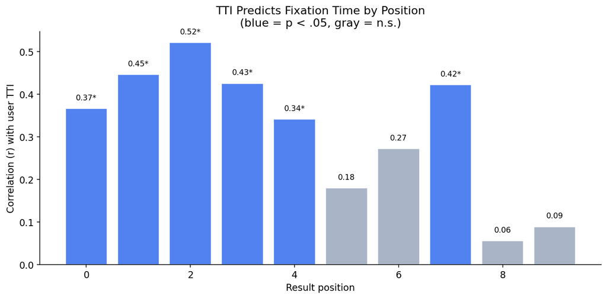

[output not shown]

```python
# Per-position: does TTI predict position-specific fixation?
fig, ax = plt.subplots(figsize=(10, 5))

pos_by_user = defaultdict(lambda: defaultdict(list))
for r in eval_rows:
    if r['fixation_ms'] > 0:
        pos_by_user[r['position']][r['pid']].append(r['fixation_ms'])

positions, r_vals, p_vals, n_vals = [], [], [], []
for pos in range(10):
    xs, ys = [], []
    for u in user_tti:
        if u['pid'] in pos_by_user[pos] and u['median_tti_move'] is not None:
            xs.append(u['median_tti_move'])
            ys.append(np.mean(pos_by_user[pos][u['pid']]))
    if len(xs) >= 10:
        rr, pp = stats.pearsonr(xs, ys)
        positions.append(pos)
        r_vals.append(rr)
        p_vals.append(pp)
        n_vals.append(len(xs))

colors = ['#2563eb' if p < 0.05 else '#94a3b8' for p in p_vals]
ax.bar(positions, r_vals, color=colors, alpha=0.8, edgecolor='white')
ax.axhline(y=0, color='black', linewidth=0.5)
ax.set_xlabel('Result position')
ax.set_ylabel('Correlation (r) with user TTI')
ax.set_title('TTI Predicts Fixation Time by Position\n(blue = p < .05, gray = n.s.)')

for pos, r, p in zip(positions, r_vals, p_vals):
    label = f'{r:.2f}' + ('*' if p < 0.05 else '')
    ax.text(pos, r + 0.02, label, ha='center', fontsize=9)

plt.tight_layout()
plt.savefig('plots-v1/plot_tti_by_position.png', dpi=200, bbox_inches='tight')
plt.show()

print("TTI predicts fixation time significantly for positions 0-7.")
print("Signal fades at 8-9 where ski-jump dynamics introduce other variance.")
```

### TTI calibrator findings

**TTI-to-first-scroll is a strong individual calibrator** (r=0.77 for fixation time, r=0.74 for viewport time). Users who are slow to start scrolling spend more time on every result they encounter. This is a stable individual trait, not noise.

**TTI-to-first-mousemove is weaker but still significant** (r=0.46). Mouse movement begins more reflexively; scrolling requires a decision ("I need to see more"), which is where processing style reveals itself.

**The first 5 trials are enough.** Calibration TTI from early trials predicts fixation time in later trials (r=0.42, p=0.003). In an applied setting, this means a search engine could estimate a user's processing speed from their first few queries and adjust expectations for engagement signals accordingly.

**Implication for the residual dwell model** (Peter Dixon-Moses): a per-user baseline for expected fixation time should incorporate TTI as a calibration feature. Users with TTI=1s have a different fixation-time baseline than users with TTI=7s — deviations from that baseline are the interest signal.

## Part 4: Evaluation Time Decomposition

Total fixation time per result = **fixation count** × **per-fixation duration**. The position effect in total fixation time could come from either component. Additionally, the *time to first fixation* on each result decomposes into an **orientation phase** (intercept) and a **scanning rate** (slope across positions).

We decompose:

1. **Time to first fixation** — when does the eye first land on each result? Regression gives orientation time (intercept) and scanning rate (slope).
2. **Fixation count** — how many fixations does each result receive?
3. **Per-fixation duration** — how long is each individual fixation?
4. **Total fixation time** — count × duration, for comparison with Part 1.

```python
# Compute per-trial, per-result decomposition: first fixation time, count, mean duration
# Reuses scroll interpolation and result band logic from Part 1

print("Computing fixation decomposition...")
decomp_rows = []

for i, tid in enumerate(trial_ids):
    if (i+1) % 500 == 0:
        print(f"  {i+1}/{len(trial_ids)}...")

    doc_h, scr_h, t0 = get_trial_meta(tid)
    if not doc_h or not scr_h or not t0:
        continue

    n_res = count_results_from_html(tid)
    if n_res < 3:
        continue

    all_events, scrolls, clicks = load_mouse_events(tid)
    if not clicks:
        continue

    scroll_ts = [s[0] for s in scrolls]
    scroll_ys = [s[1] for s in scrolls]

    bands = result_bands(n_res, doc_h)
    tops = [b[0] for b in bands]

    # Determine visibility per result
    max_scroll_y = max((s[1] for s in scrolls), default=0) + scr_h
    first_vp_n = sum(1 for r_top, r_bot in bands if r_top < scr_h)
    max_scroll_before_click = max((sy for st, sy in scrolls if st < clicks[-1][0]), default=0)
    is_fv = max_scroll_before_click < 50

    if is_fv:
        visible_limit = first_vp_n
    else:
        visible_limit = sum(1 for r_top, r_bot in bands if r_top < max_scroll_y)

    pid = tid.split('-')[0]

    # Track per-result: first fixation timestamp, count, total duration
    first_fix_t = {}   # pos -> earliest fixation timestamp (ms, absolute)
    fix_count = defaultdict(int)
    fix_total = defaultdict(float)

    fp = os.path.join(FIXATION_DIR, f'{tid}.csv')
    if not os.path.exists(fp):
        continue
    with open(fp) as f:
        for row in csv.DictReader(f):
            try:
                ft = int(float(row['timestamp']))
                fy = float(row['FPOGY'])
                fd = float(row['FPOGD'])
            except:
                continue
            page_y = fy + interpolate_scroll(ft, scroll_ts, scroll_ys)
            pos = bisect_right(tops, page_y) - 1
            if 0 <= pos < n_res:
                fix_count[pos] += 1
                fix_total[pos] += fd
                if pos not in first_fix_t or ft < first_fix_t[pos]:
                    first_fix_t[pos] = ft

    # t0 in this notebook is the page-load timestamp (ms since epoch)
    # fixation timestamps are also ms since epoch
    t0_ms = t0 * 1000 if t0 < 1e10 else t0  # handle seconds vs ms

    for pos in range(min(n_res, 10)):
        if pos >= visible_limit:
            continue  # not visible to this user
        if fix_count[pos] == 0:
            continue  # no fixations on this result

        first_ms = first_fix_t[pos] - t0_ms if pos in first_fix_t else None
        mean_dur = fix_total[pos] / fix_count[pos] if fix_count[pos] > 0 else 0

        decomp_rows.append({
            'pid': pid,
            'trial': tid,
            'position': pos,
            'is_fv': is_fv,
            'first_fix_ms': first_ms,
            'fix_count': fix_count[pos],
            'fix_total_ms': fix_total[pos],
            'mean_fix_dur': mean_dur,
        })

print(f"Decomposition rows: {len(decomp_rows)}")
print(f"  FV trials: {len(set(r['trial'] for r in decomp_rows if r['is_fv']))}")
print(f"  Scrolled:  {len(set(r['trial'] for r in decomp_rows if not r['is_fv']))}")
```

```
Computing fixation decomposition...
```

```
  500/2776...
```

```
  1000/2776...
```

```
  1500/2776...
```

```
  2000/2776...
```

```
  2500/2776...
```

```
Decomposition rows: 17371
  FV trials: 508
  Scrolled:  2262
```

```python
# Regression: first_fix_ms ~ position, separately for FV and scrolled
# Intercept = orientation time, slope = scanning rate

fv_pos, fv_ffms = [], []
sc_pos, sc_ffms = [], []

for r in decomp_rows:
    if r['first_fix_ms'] is not None and 0 < r['first_fix_ms'] < 30000:
        if r['is_fv']:
            fv_pos.append(r['position'])
            fv_ffms.append(r['first_fix_ms'])
        else:
            sc_pos.append(r['position'])
            sc_ffms.append(r['first_fix_ms'])

fv_slope, fv_intercept, fv_r, fv_p, fv_se = stats.linregress(fv_pos, fv_ffms)
sc_slope, sc_intercept, sc_r, sc_p, sc_se = stats.linregress(sc_pos, sc_ffms)

print("=== Time to First Fixation ~ Position ===")
print(f"\nFirst-viewport clickers:")
print(f"  Intercept (orientation): {fv_intercept:.0f} ms")
print(f"  Slope (scanning rate):   {fv_slope:.0f} ms/position")
print(f"  r = {fv_r:.3f}, p = {fv_p:.2e}")
print(f"\nScrollers:")
print(f"  Intercept (orientation): {sc_intercept:.0f} ms")
print(f"  Slope (scanning rate):   {sc_slope:.0f} ms/position")
print(f"  r = {sc_r:.3f}, p = {sc_p:.2e}")

# Per-fixation duration by position
print("\n=== Mean Single-Fixation Duration by Position ===")
for grp_name, is_fv_val in [("FV clickers", True), ("Scrollers", False)]:
    durs_by_pos = defaultdict(list)
    for r in decomp_rows:
        if r['is_fv'] == is_fv_val:
            durs_by_pos[r['position']].append(r['mean_fix_dur'])
    vals = [np.mean(durs_by_pos[p]) for p in range(10) if durs_by_pos[p]]
    print(f"  {grp_name}: {[f'{v:.0f}' for v in vals]}")
    print(f"    Range: {min(vals):.0f} – {max(vals):.0f} ms")

# Fixation count by position
print("\n=== Fixation Count by Position ===")
for grp_name, is_fv_val in [("FV clickers", True), ("Scrollers", False)]:
    counts_by_pos = defaultdict(list)
    for r in decomp_rows:
        if r['is_fv'] == is_fv_val:
            counts_by_pos[r['position']].append(r['fix_count'])
    vals = [np.mean(counts_by_pos[p]) for p in range(10) if counts_by_pos[p]]
    print(f"  {grp_name}: {[f'{v:.1f}' for v in vals]}")
```

```
=== Time to First Fixation ~ Position ===

First-viewport clickers:
  Intercept (orientation): 1665 ms
  Slope (scanning rate):   2488 ms/position
  r = 0.525, p = 7.84e-108

Scrollers:
  Intercept (orientation): 2997 ms
  Slope (scanning rate):   1559 ms/position
  r = 0.602, p = 0.00e+00

=== Mean Single-Fixation Duration by Position ===
  FV clickers: ['212', '231', '247', '262', '266', '201']
    Range: 201 – 266 ms
  Scrollers: ['202', '216', '223', '222', '225', '225', '228', '222', '226', '216']
    Range: 202 – 228 ms

=== Fixation Count by Position ===
  FV clickers: ['17.1', '13.3', '8.7', '5.9', '4.4', '1.0']
  Scrollers: ['17.2', '12.7', '10.1', '9.1', '8.1', '7.5', '6.7', '6.2', '5.7', '7.0']
```

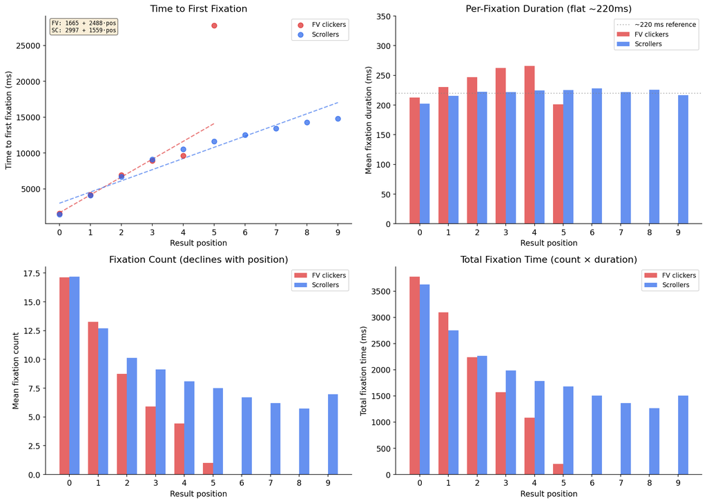

```
Saved: plots-v1/plot_decomposition.png
```

```python
# 2x2 decomposition figure
fig, axes = plt.subplots(2, 2, figsize=(14, 10))

positions = range(10)
x = np.arange(10)
w = 0.35

# --- Top-left: Time to first fixation by position ---
ax = axes[0, 0]

# Aggregate by position
fv_ff_by_pos = defaultdict(list)
sc_ff_by_pos = defaultdict(list)
for r in decomp_rows:
    if r['first_fix_ms'] is not None and 0 < r['first_fix_ms'] < 30000:
        target = fv_ff_by_pos if r['is_fv'] else sc_ff_by_pos
        target[r['position']].append(r['first_fix_ms'])

fv_ff_means = [np.mean(fv_ff_by_pos[p]) if fv_ff_by_pos[p] else np.nan for p in positions]
sc_ff_means = [np.mean(sc_ff_by_pos[p]) if sc_ff_by_pos[p] else np.nan for p in positions]

ax.scatter([p for p in positions if fv_ff_by_pos[p]],
           [m for m in fv_ff_means if not np.isnan(m)],
           color='#dc2626', alpha=0.7, s=50, zorder=3, label='FV clickers')
ax.scatter([p for p in positions if sc_ff_by_pos[p]],
           [m for m in sc_ff_means if not np.isnan(m)],
           color='#2563eb', alpha=0.7, s=50, zorder=3, label='Scrollers')

# Regression lines
fv_x_line = np.linspace(0, max(p for p in positions if fv_ff_by_pos[p]), 50)
sc_x_line = np.linspace(0, 9, 50)
ax.plot(fv_x_line, fv_intercept + fv_slope * fv_x_line, '--', color='#dc2626', alpha=0.6)
ax.plot(sc_x_line, sc_intercept + sc_slope * sc_x_line, '--', color='#2563eb', alpha=0.6)

ax.set_xlabel('Result position')
ax.set_ylabel('Time to first fixation (ms)')
ax.set_title('Time to First Fixation')
ax.legend(fontsize=9)
ax.set_xticks(x)
ax.text(0.02, 0.98, f'FV: {fv_intercept:.0f} + {fv_slope:.0f}·pos\nSC: {sc_intercept:.0f} + {sc_slope:.0f}·pos',
        transform=ax.transAxes, va='top', fontsize=8, family='monospace',
        bbox=dict(boxstyle='round', facecolor='wheat', alpha=0.5))

# --- Top-right: Mean single-fixation duration by position ---
ax = axes[0, 1]

fv_dur_by_pos = defaultdict(list)
sc_dur_by_pos = defaultdict(list)
for r in decomp_rows:
    target = fv_dur_by_pos if r['is_fv'] else sc_dur_by_pos
    target[r['position']].append(r['mean_fix_dur'])

fv_dur_means = [np.mean(fv_dur_by_pos[p]) if fv_dur_by_pos[p] else 0 for p in positions]
sc_dur_means = [np.mean(sc_dur_by_pos[p]) if sc_dur_by_pos[p] else 0 for p in positions]

ax.bar(x - w/2, fv_dur_means, w, color='#dc2626', alpha=0.7, label='FV clickers')
ax.bar(x + w/2, sc_dur_means, w, color='#2563eb', alpha=0.7, label='Scrollers')
ax.axhline(y=220, color='gray', linestyle=':', alpha=0.5, label='~220 ms reference')
ax.set_xlabel('Result position')
ax.set_ylabel('Mean fixation duration (ms)')
ax.set_title('Per-Fixation Duration (flat ~220ms)')
ax.legend(fontsize=9)
ax.set_xticks(x)
ax.set_ylim(0, 350)

# --- Bottom-left: Fixation count by position ---
ax = axes[1, 0]

fv_cnt_by_pos = defaultdict(list)
sc_cnt_by_pos = defaultdict(list)
for r in decomp_rows:
    target = fv_cnt_by_pos if r['is_fv'] else sc_cnt_by_pos
    target[r['position']].append(r['fix_count'])

fv_cnt_means = [np.mean(fv_cnt_by_pos[p]) if fv_cnt_by_pos[p] else 0 for p in positions]
sc_cnt_means = [np.mean(sc_cnt_by_pos[p]) if sc_cnt_by_pos[p] else 0 for p in positions]

ax.bar(x - w/2, fv_cnt_means, w, color='#dc2626', alpha=0.7, label='FV clickers')
ax.bar(x + w/2, sc_cnt_means, w, color='#2563eb', alpha=0.7, label='Scrollers')
ax.set_xlabel('Result position')
ax.set_ylabel('Mean fixation count')
ax.set_title('Fixation Count (declines with position)')
ax.legend(fontsize=9)
ax.set_xticks(x)

# --- Bottom-right: Total fixation time by position ---
ax = axes[1, 1]

fv_tot_by_pos = defaultdict(list)
sc_tot_by_pos = defaultdict(list)
for r in decomp_rows:
    target = fv_tot_by_pos if r['is_fv'] else sc_tot_by_pos
    target[r['position']].append(r['fix_total_ms'])

fv_tot_means = [np.mean(fv_tot_by_pos[p]) if fv_tot_by_pos[p] else 0 for p in positions]
sc_tot_means = [np.mean(sc_tot_by_pos[p]) if sc_tot_by_pos[p] else 0 for p in positions]

ax.bar(x - w/2, fv_tot_means, w, color='#dc2626', alpha=0.7, label='FV clickers')
ax.bar(x + w/2, sc_tot_means, w, color='#2563eb', alpha=0.7, label='Scrollers')
ax.set_xlabel('Result position')
ax.set_ylabel('Total fixation time (ms)')
ax.set_title('Total Fixation Time (count × duration)')
ax.legend(fontsize=9)
ax.set_xticks(x)

plt.tight_layout()
plt.savefig('plots-v1/plot_decomposition.png', dpi=200, bbox_inches='tight')
plt.show()

print("Saved: plots-v1/plot_decomposition.png")
```

### Decomposition findings

**The position effect in fixation time is driven by fixation count, not fixation duration.**

This decomposition matters for modeling: position bias in click-through rates propagates through *number of looks*, not through *quality of each look*. A result at position 8 gets the same depth of processing per fixation as position 0 — it just gets fewer chances.

## Summary

**Fixation coverage:** 95% of results above the clicked result get fixated. Users do a genuine sequential scan — the cumulative lexical exposure measured in the priming notebook is real, not hypothetical. Skip rate plateaus at ~20% for mid-page positions (4-9).

**The first 2 seconds** are dominated by mouse movement for both groups. Scrollers begin scrolling gradually (ramping from 0.5s onward). Neither group clicks within the first 2 seconds — there's always an initial evaluation phase. In unconstrained browsing, this window is typically a "should I stay or should I go" decision point: assess the SERP, then either engage or reformulate. The forced-click task eliminates the reformulation exit, so here the 2s window is pure assessment, never abandonment. The *duration* of this phase may still reflect individual processing speed (see Part 3), but its *function* is narrower than in real search.